# Python_Southern_Water_Corp_Case_Study_Part 2

## 15.9: Southern Water Corp Case Study: Inferential Stats with Python

Unable to upload all the code in one file, Separating from Part2

### Step 1: Import Libraries

```python
import matplotlib as mpl
import matplotlib.pyplot as plt
import matplotlib.dates as md
from matplotlib.dates import DateFormatter
%matplotlib inline
import numpy as np
import seaborn as sns
import pandas as pd
import statsmodels.api as sm
```

### Step2: Upload files

```python
import pandas as pd
dataframe_1 = pd.read_csv(r'C:\Users\marik\OneDrive\Desktop\Springboard Projects\Unit 15\Python case study_students\Desalination_Unit_File_001.csv',header=1, index_col = 'TIMEFRAME')
dataframe_2 = pd.read_csv(r'C:\Users\marik\OneDrive\Desktop\Springboard Projects\Unit 15\Python case study_students\Desalination_Unit_File_002.csv',header=1, index_col = 'TIMEFRAME')
dataframe_3 = pd.read_csv(r'C:\Users\marik\OneDrive\Desktop\Springboard Projects\Unit 15\Python case study_students\Desalination_Unit_File_003.csv',header=1, index_col = 'TIMEFRAME')
df = pd.concat([dataframe_1, dataframe_2, dataframe_3])
df = df.dropna()
df = df.reset_index(drop=True)

print(df.info())
```

```
<class 'pandas.core.frame.DataFrame'>
RangeIndex: 6997 entries, 0 to 6996
Data columns (total 9 columns):
 #   Column                       Non-Null Count  Dtype
---  ------                       --------------  -----
 0   SURJEK_FLOW_METER_1          6997 non-null   float64
 1   SURJEK_FLOW_METER_2          6997 non-null   float64
 2   ROTATIONAL_PUMP_RPM          6997 non-null   float64
 3   SURJEK_PUMP_TORQUE           6997 non-null   float64
 4   MAXIMUM_DAILY_PUMP_TORQUE    6997 non-null   float64
 5   SURJEK_AMMONIA_FLOW_RATE     6997 non-null   int64
 6   SURJEK_TUBE_PRESSURE         6997 non-null   float64
 7   SURJEK_ESTIMATED_EFFICIENCY  6997 non-null   float64
 8   PUMP FAILURE (1 or 0)        6997 non-null   float64
dtypes: float64(8), int64(1)
memory usage: 492.1 KB
None
```

### Step10: Create a Plot for Pump Failures Over a Rolling Time Period

leave this code here so I can use r30

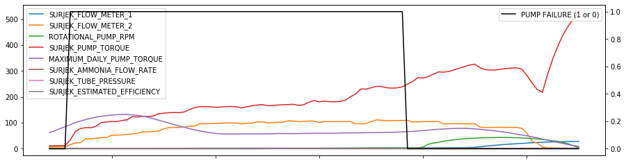

```python
dataframe_1 = pd.read_csv(r'C:\Users\marik\OneDrive\Desktop\Springboard Projects\Unit 15\Python case study_students\Desalination_Unit_File_001.csv',header=1)
dataframe_2 = pd.read_csv(r'C:\Users\marik\OneDrive\Desktop\Springboard Projects\Unit 15\Python case study_students\Desalination_Unit_File_002.csv',header=1)
dataframe_3 = pd.read_csv(r'C:\Users\marik\OneDrive\Desktop\Springboard Projects\Unit 15\Python case study_students\Desalination_Unit_File_003.csv',header=1)
df = pd.concat([dataframe_1, dataframe_2, dataframe_3])
df = df.dropna()
df = df.reset_index(drop=True)

#Below is the first part of the code
from datetime import datetime
df['TIMEFRAME'] = pd.to_datetime(df['TIMEFRAME']).apply(lambda x: x.strftime('%d/%m/%Y %H:%M:%S')if not pd.isnull(x) else '')
filt = ['SURJEK_FLOW_METER_1', 'SURJEK_FLOW_METER_2', 'ROTATIONAL_PUMP_RPM',
       'SURJEK_PUMP_TORQUE', 'MAXIMUM_DAILY_PUMP_TORQUE',
       'SURJEK_AMMONIA_FLOW_RATE', 'SURJEK_TUBE_PRESSURE',
       'SURJEK_ESTIMATED_EFFICIENCY','PUMP FAILURE (1 or 0)', 'TIMEFRAME']
filt2 = ['PUMP FAILURE (1 or 0)']
filt3 = ['SURJEK_FLOW_METER_1', 'SURJEK_FLOW_METER_2', 'ROTATIONAL_PUMP_RPM',
       'SURJEK_PUMP_TORQUE', 'MAXIMUM_DAILY_PUMP_TORQUE',
       'SURJEK_AMMONIA_FLOW_RATE', 'SURJEK_TUBE_PRESSURE',
       'SURJEK_ESTIMATED_EFFICIENCY']
colList = df[filt3].columns
plt.rcParams['figure.figsize'] = (15,4)

#----write your code below-------

# i) Apply a rolling standard deviation to the dataframe using a rolling window size of '30'
r30= df[filt3].rolling(window=30).std()

#i) Re-plot all variables for the time period 10/12/2014 14:40 to 10/12/2014 14:45, focusing specifically on the first Pump “Failure”.

r30['TIMEFRAME'] = df['TIMEFRAME']
r30['PUMP FAILURE (1 or 0)'] = df['PUMP FAILURE (1 or 0)']
r30.dropna(inplace = True)
r30_filt_time = r30.loc[(r30['TIMEFRAME'] >= '12/10/2014 14:40') & (r30['TIMEFRAME'] <= '12/10/2014 14:45')]
fig,ax = plt.subplots()

#Loop through the Plot
for col in colList:
    ax.plot(r30_filt_time[col], label = col)

ax2 = ax.twinx()
ax2.plot(r30_filt_time[filt2], color = 'black', label = 'PUMP FAILURE (1 or 0)')
ax.legend(loc= 'best')
ax2.legend(loc='upper right')
plt.setp(ax.get_xticklabels(), visible = False)
plt.show()
```

## Part II: Inferential Statistical Analysis

When you performed inferential statistics for Southern Water Corp using Excel, you made use of the data analysis package to create a heatmap using the correlation function. The heatmap showed the attributes that strongly correlated to Pump Failure.

Now, you'll create a heatmap using Seaborn's heatmap function — another testament to the fact that having Matplotlib and Seaborn in your toolbox will allow you to quickly create beautiful graphics that provide key insights.

### Step 11: Create a Heatmap

i) Using Seaborn's heatmap function, create a heatmap that clearly shows the correlations (including R Squared) for all variables (excluding those with consistent 0 values such as Ammonia Flow Rate).

**Note:** We have provided the filter list and created the dataframe for you.

Link: (https://seaborn.pydata.org/generated/seaborn.heatmap.html)

## Please put your code here

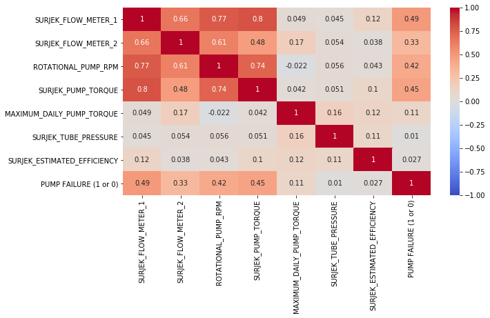

```python
#from datetime import datetime
#df['TIMEFRAME'] = pd.to_datetime(df['TIMEFRAME']).apply(lambda x: x.strftime('%d/%m/%Y %H:%M:%S')if not pd.isnull(x) else '')

plt.rcParams['figure.figsize'] = (10,5)
filt = ['SURJEK_FLOW_METER_1', 'SURJEK_FLOW_METER_2', 'ROTATIONAL_PUMP_RPM',
       'SURJEK_PUMP_TORQUE', 'MAXIMUM_DAILY_PUMP_TORQUE',
       'SURJEK_TUBE_PRESSURE',
       'SURJEK_ESTIMATED_EFFICIENCY','PUMP FAILURE (1 or 0)']

dataframe = df[filt]

correlation = dataframe.corr()
sns.heatmap(correlation, annot = True, vmin=-1, vmax=1, center= 0, cmap= 'coolwarm')
plt.show()
```

**Open-ended Question:**

Which variables seem to correlate with Pump Failure?

Answer: Surjek_Flow_Meter_1, Surjek_Flow_Meter_2, Rotational_Pump_RPM, Surjek_Pump_Torque

### Step 12: Create a Barplot of Correlated Features

Create a barplot that shows the correlated features against PUMP FAILURE (1 or 0), in descending order.

### Please put your code here

```
                             PUMP FAILURE (1 or 0)
SURJEK_FLOW_METER_1                       0.494103
SURJEK_PUMP_TORQUE                        0.452760
ROTATIONAL_PUMP_RPM                       0.417383
SURJEK_FLOW_METER_2                       0.326739
MAXIMUM_DAILY_PUMP_TORQUE                 0.107461
SURJEK_ESTIMATED_EFFICIENCY               0.027132
SURJEK_TUBE_PRESSURE                      0.009965
```

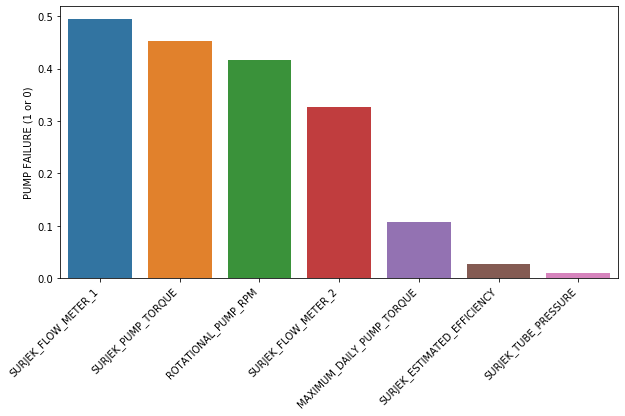

```python
#correlation = dataframe.corr()
#print(correlation)
pump_failure = correlation.filter(items=['PUMP FAILURE (1 or 0)'])
pump_failure = pump_failure[pump_failure['PUMP FAILURE (1 or 0)'] != 1.0]
pump_failure.sort_values(by ='PUMP FAILURE (1 or 0)', ascending=False, inplace=True)
print(pump_failure)

sns.barplot(x=pump_failure.index, y='PUMP FAILURE (1 or 0)', data=pump_failure)
plt.xticks(rotation=45, ha='right')
plt.show()
```

```python
correlation
```

|  | SURJEK_FLOW_METER_1 | SURJEK_FLOW_METER_2 | ROTATIONAL_PUMP_RPM | SURJEK_PUMP_TORQUE | MAXIMUM_DAILY_PUMP_TORQUE | SURJEK_TUBE_PRESSURE | SURJEK_ESTIMATED_EFFICIENCY | PUMP FAILURE (1 or 0) |
| --- | --- | --- | --- | --- | --- | --- | --- | --- |
| SURJEK_FLOW_METER_1 | 1.000000 | 0.663673 | 0.767180 | 0.801860 | 0.048709 | 0.044880 | 0.122017 | 0.494103 |
| SURJEK_FLOW_METER_2 | 0.663673 | 1.000000 | 0.610079 | 0.482345 | 0.171442 | 0.054388 | 0.038210 | 0.326739 |
| ROTATIONAL_PUMP_RPM | 0.767180 | 0.610079 | 1.000000 | 0.737254 | -0.021759 | 0.055541 | 0.043148 | 0.417383 |
| SURJEK_PUMP_TORQUE | 0.801860 | 0.482345 | 0.737254 | 1.000000 | 0.042194 | 0.050721 | 0.101758 | 0.452760 |
| MAXIMUM_DAILY_PUMP_TORQUE | 0.048709 | 0.171442 | -0.021759 | 0.042194 | 1.000000 | 0.156467 | 0.119161 | 0.107461 |
| SURJEK_TUBE_PRESSURE | 0.044880 | 0.054388 | 0.055541 | 0.050721 | 0.156467 | 1.000000 | 0.108175 | 0.009965 |
| SURJEK_ESTIMATED_EFFICIENCY | 0.122017 | 0.038210 | 0.043148 | 0.101758 | 0.119161 | 0.108175 | 1.000000 | 0.027132 |
| PUMP FAILURE (1 or 0) | 0.494103 | 0.326739 | 0.417383 | 0.452760 | 0.107461 | 0.009965 | 0.027132 | 1.000000 |

### Step 13: Create a Rolling Standard Deviation Heatmap

Previously, you created a correlation matrix using 'raw' variables. This time, you'll transform 'raw' variables using a rolling standard deviation.

i) Apply a rolling standard deviation to the dataframe using a rolling window size of '30'.

ii) Using the newly created rolling standard deviation dataframe, use the Seaborn heatmap function to replot this dataframe into a heatmap.

Do any variables stand out? If yes, list these out below your heatmap.

**Note:** We have provided the initial dataframe and filters.

## Please put your code here

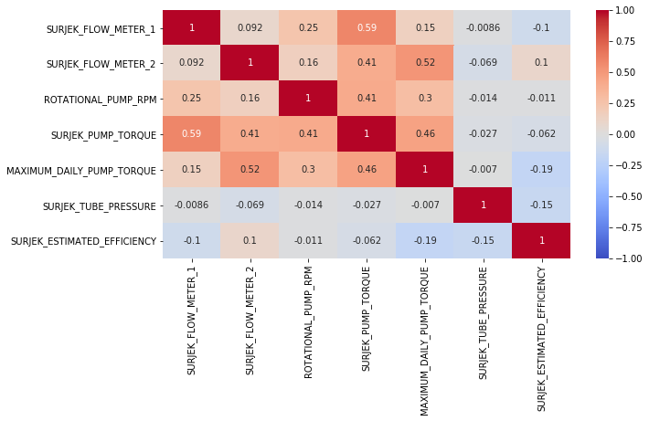

```python
filt3 = ['SURJEK_FLOW_METER_1', 'SURJEK_FLOW_METER_2', 'ROTATIONAL_PUMP_RPM',
       'SURJEK_PUMP_TORQUE', 'MAXIMUM_DAILY_PUMP_TORQUE',
       'SURJEK_AMMONIA_FLOW_RATE', 'SURJEK_TUBE_PRESSURE',
       'SURJEK_ESTIMATED_EFFICIENCY']
r30= df[filt3].rolling(window=30).std()

plt.rcParams['figure.figsize'] = (10,5)
filt = ['SURJEK_FLOW_METER_1', 'SURJEK_FLOW_METER_2', 'ROTATIONAL_PUMP_RPM',
       'SURJEK_PUMP_TORQUE', 'MAXIMUM_DAILY_PUMP_TORQUE',
       'SURJEK_TUBE_PRESSURE',
       'SURJEK_ESTIMATED_EFFICIENCY']
r30 = r30[filt]

sns.heatmap(r30.corr(), annot = True, vmin=-1, vmax=1, center= 0, cmap= 'coolwarm')
plt.show()
```

### Creating a Multivariate Regression Model

When you worked on this case study in Excel, you went through the tricky process of using the rolling standard deviation variables to generate a regression equation. Happily, this process is much simpler in Python.

For this step, you'll be using the statsmodel.api library you imported earlier and calling the Ordinary Least Squares Regression to create a multivariate regression model (which is a linear regression model with more than one independent variable).

### Step 14: Use OLS Regression

i) Using the OLS Regression Model in the statsmodel.api library, create a regression equation that models the Pump Failure (Y-Variable) against all your independent variables, which include every other variable that is not PUMP FAILURE (1 or 0). What is the R Squared for the model and what does this signify?

ii) Repeat i) but this time use the rolling standard deviation variables you created previously. What is the R Squared for the model and what does this signify?

**Open-ended Question:**

Which linear regression model seems to be a better fit?

**Note:** We have provided the initial dataframe and filter list.

## Please put your code here

```python
filt = ['SURJEK_FLOW_METER_1', 'SURJEK_FLOW_METER_2', 'ROTATIONAL_PUMP_RPM',
       'SURJEK_PUMP_TORQUE', 'MAXIMUM_DAILY_PUMP_TORQUE',
       'SURJEK_AMMONIA_FLOW_RATE', 'SURJEK_TUBE_PRESSURE',
       'SURJEK_ESTIMATED_EFFICIENCY' ]

x= df[filt]
y= df['PUMP FAILURE (1 or 0)']
x= sm.add_constant(x)
model= sm.OLS(y,x).fit()
model.summary()
```

OLS Regression Results

| Dep. Variable: | PUMP FAILURE (1 or 0) | R-squared: | 0.264 |
| --- | --- | --- | --- |
| Model: | OLS | Adj. R-squared: | 0.264 |
| Method: | Least Squares | F-statistic: | 358.8 |
| Date: | Sun, 12 Apr 2020 | Prob (F-statistic): | 0.00 |
| Time: | 18:07:09 | Log-Likelihood: | 7547.4 |
| No. Observations: | 6997 | AIC: | -1.508e+04 |
| Df Residuals: | 6989 | BIC: | -1.502e+04 |
| Df Model: | 7 |  |  |
| Covariance Type: | nonrobust |  |  |

|  | coef | std err | t | P>\|t\| | [0.025 | 0.975] |
| --- | --- | --- | --- | --- | --- | --- |
| const | 0.1293 | 0.056 | 2.318 | 0.020 | 0.020 | 0.239 |
| SURJEK_FLOW_METER_1 | 0.0017 | 9.98e-05 | 16.795 | 0.000 | 0.001 | 0.002 |
| SURJEK_FLOW_METER_2 | -0.0001 | 5.77e-05 | -2.084 | 0.037 | -0.000 | -7.14e-06 |
| ROTATIONAL_PUMP_RPM | 0.0003 | 8.17e-05 | 4.110 | 0.000 | 0.000 | 0.000 |
| SURJEK_PUMP_TORQUE | 0.0001 | 1.43e-05 | 7.011 | 0.000 | 7.23e-05 | 0.000 |
| MAXIMUM_DAILY_PUMP_TORQUE | 2.036e-05 | 2.18e-06 | 9.322 | 0.000 | 1.61e-05 | 2.46e-05 |
| SURJEK_AMMONIA_FLOW_RATE | 3.803e-19 | 1.49e-19 | 2.559 | 0.011 | 8.9e-20 | 6.72e-19 |
| SURJEK_TUBE_PRESSURE | -0.0004 | 0.000 | -2.516 | 0.012 | -0.001 | -8.17e-05 |
| SURJEK_ESTIMATED_EFFICIENCY | -0.0052 | 0.001 | -3.865 | 0.000 | -0.008 | -0.003 |

| Omnibus: | 7981.939 | Durbin-Watson: | 0.045 |
| --- | --- | --- | --- |
| Prob(Omnibus): | 0.000 | Jarque-Bera (JB): | 972152.905 |
| Skew: | 5.870 | Prob(JB): | 0.00 |
| Kurtosis: | 59.539 | Cond. No. | 1.02e+18 |

Warnings:  
[1] Standard Errors assume that the covariance matrix of the errors is correctly specified.  
[2] The smallest eigenvalue is 3.27e-27. This might indicate that there are  
strong multicollinearity problems or that the design matrix is singular.

```python
filt3 = ['SURJEK_FLOW_METER_1', 'SURJEK_FLOW_METER_2', 'ROTATIONAL_PUMP_RPM',
       'SURJEK_PUMP_TORQUE', 'MAXIMUM_DAILY_PUMP_TORQUE',
       'SURJEK_AMMONIA_FLOW_RATE', 'SURJEK_TUBE_PRESSURE',
       'SURJEK_ESTIMATED_EFFICIENCY']

r30_x= r30[filt3]
r30_y= r30['PUMP FAILURE (1 or 0)']

x= sm.add_constant(r30_x)
r30_model= sm.OLS(r30_y,r30_x).fit()
r30_model.summary()
```

OLS Regression Results

| Dep. Variable: | PUMP FAILURE (1 or 0) | R-squared (uncentered): | 0.623 |
| --- | --- | --- | --- |
| Model: | OLS | Adj. R-squared (uncentered): | 0.622 |
| Method: | Least Squares | F-statistic: | 1640. |
| Date: | Sun, 12 Apr 2020 | Prob (F-statistic): | 0.00 |
| Time: | 18:17:05 | Log-Likelihood: | 9793.6 |
| No. Observations: | 6968 | AIC: | -1.957e+04 |
| Df Residuals: | 6961 | BIC: | -1.953e+04 |
| Df Model: | 7 |  |  |
| Covariance Type: | nonrobust |  |  |

|  | coef | std err | t | P>\|t\| | [0.025 | 0.975] |
| --- | --- | --- | --- | --- | --- | --- |
| SURJEK_FLOW_METER_1 | -0.0031 | 0.000 | -9.285 | 0.000 | -0.004 | -0.002 |
| SURJEK_FLOW_METER_2 | 0.0016 | 6.43e-05 | 24.208 | 0.000 | 0.001 | 0.002 |
| ROTATIONAL_PUMP_RPM | -0.0066 | 0.000 | -30.864 | 0.000 | -0.007 | -0.006 |
| SURJEK_PUMP_TORQUE | 0.0003 | 2.56e-05 | 11.071 | 0.000 | 0.000 | 0.000 |
| MAXIMUM_DAILY_PUMP_TORQUE | 0.0057 | 8.77e-05 | 65.361 | 0.000 | 0.006 | 0.006 |
| SURJEK_AMMONIA_FLOW_RATE | 7.635e-18 | 1.01e-18 | 7.556 | 0.000 | 5.65e-18 | 9.62e-18 |
| SURJEK_TUBE_PRESSURE | -0.0017 | 0.000 | -3.766 | 0.000 | -0.003 | -0.001 |
| SURJEK_ESTIMATED_EFFICIENCY | -0.0144 | 0.002 | -7.931 | 0.000 | -0.018 | -0.011 |

| Omnibus: | 3048.011 | Durbin-Watson: | 0.083 |
| --- | --- | --- | --- |
| Prob(Omnibus): | 0.000 | Jarque-Bera (JB): | 402139.069 |
| Skew: | 1.070 | Prob(JB): | 0.00 |
| Kurtosis: | 40.155 | Cond. No. | 9.65e+18 |

Warnings:  
[1] Standard Errors assume that the covariance matrix of the errors is correctly specified.  
[2] The smallest eigenvalue is 1.38e-31. This might indicate that there are  
strong multicollinearity problems or that the design matrix is singular.

Great job creating those regressive equations! You've reached the final step of this case study!

### Step 15: Validate Predictions

i) Use the regression equation you created in the previous step and apply the .predict() function to the dataframe to see whether or not your model 'picks' up the Pump Failure Event.

ii) Plot the rolling linear regression equation against the attribute 'PUMP FAILURE (1 or 0)'

**Note:** Please ensure all axes are clearly labelled and ensure that you use Dual Axes to plot this. Make the line widths wider than 1 so the plots are easier to see. We have provided the initial figure size.

## Please put your code here

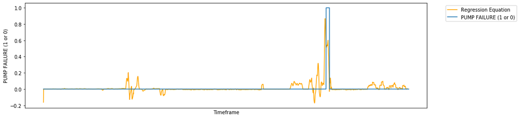

```python
#Below is the first part of the code
mpl.rcParams['figure.figsize'] = (15,4)

predict = r30_model.predict()
actual_data = df['PUMP FAILURE (1 or 0)']

plt.plot(predict, color ='orange', label = 'Regression Equation')
plt.plot(actual_data, label = 'PUMP FAILURE (1 or 0)')
plt.xlabel('Timeframe')
plt.ylabel('PUMP FAILURE (1 or 0)')
plt.legend(bbox_to_anchor=(1.04,1), loc="upper left")
plt.xticks([])
plt.show()
```

You've made it to the end of this challenging case study — well done! You've now converted all of the analysis you did for Southern Water Corp using Excel into Python. You created visualizations using Seaborn, manipulated datasets with pandas, and so much more! This case study was designed to give you practice using Python to analyze datasets both large and small — you can now apply these skills to work you do throughout your career as a data analyst.

## Great job! Being able to complete this case study means that you're now fluent in Python for data analysis! Congratulations!